# Circular Dataset Structures

James Foster

2026-10-23

# Details

**DESCRIPTION**

Examination of different dataset structures that may arise in the study of animal navigation.

**INPUTS**

`unwrap_functions.R`

**OUTPUTS**

Plotted results.

**REFERENCES**

**data types (inspired by)**

Duelli P & Wehner R (1973) The Spectral Sensitivity of Polarized Light Orientation in Cataglyphis bicolor (Formicidae , Hymenoptera ) *Journal of Comparative Physiology* 53(3) 37-53

Papi F & Pardi L (1963). On the Lunar Orientation of Sandhoppers (Amphipoda Talitridae). *Biol. Bull.* 124, 97–105. https://doi.org/10.2307/1539571.

Edrich W, Neumeyer C & von Helversen, O. (1979) “Anti-sun orientation” of bees with regard to a field of ultraviolet light. *J. Comp. Physiol.* 134, 151–157.

Dreyer D, Frost B, Mouritsen H, Günther A, Green K, Whitehouse M, Johnsen S, Heinze S & Warrant E (2018) The Earth’s Magnetic Field and Visual Landmarks Steer Migratory Flight Behavior in the Nocturnal Australian Bogong Moth. *Current Biology* *28*, 2160-2166.e5. https://doi.org/10.1016/j.cub.2018.05.030.

Baird E, Byrne MJ, Scholtz CH, Warrant E, Dacke M (2010) Bearing selection in ball-rolling dung beetles: is it constant? *Journal of Comparative Physiology A* 196:801–6. https://doi.org/10.1007/s00359-010-0559-8

Giraldo YM, Leitch KJ, Ros IG, Warren TL, Weir PT & Dickinson M H (2018). Sun Navigation Requires Compass Neurons in Drosophila. *Current Biology* 28, 2845-2852.e4.

Kishkinev D, Packmor F, Zechmeister T, Winkler H-C, Chernetsov N, Mouritsen H & Holland RA (2021) Navigation by extrapolation of geomagnetic cues in a migratory songbird. *Current Biology* 12(31) 7, 1563-1569.e4 https://doi.org/10.1016/j.cub.2021.01.051

**modelling methods**

Sayin S, Couzin-Fuchs E, Petelski I, Günzel Y, Salahshour M, Lee CY, Graving JM, Li L, Deussen O, Sword GA, et al. (2025) The behavioral mechanisms governing collective motion in swarming locusts. *Science* 387(6737):995–791

Gabry J, Češnovar R, Johnson A (2022). cmdstanr: R Interface to ‘CmdStan’. https://mc-stan.org/cmdstanr/

Bürkner, P.-C. (2018). Advanced Bayesian Multilevel Modeling with the R Package brms. *The R Journal* 10, 395–411.

Carpenter, B., Gelman, A., Hoffman, M. D., Lee, D., Goodrich, B., Betancourt, M., Brubaker, M., Guo, J., Li, P. and Riddell, A. (2017). Stan: A Probabilistic Programming Language. *Journal of Statistical Software* 76 doi: 10.18637/jss.v076.i01

Vehtari, A., Gelman, A., and Gabry, J. (2017) Practical Bayesian model evaluation using leave-one-out cross-validation and WAIC. *Statistics and Computing* 27(5), 1413–1432. doi:10.1007/s11222-016-9696-4.

Paananen, T., Piironen, J., Buerkner, P.-C., Vehtari, A. (2021). Implicitly adaptive importance sampling. *Statistics and Computing* 31, 16. doi:10.1007/s11222-020-09982-2.

# Motivation

These simulated circular datasets provide examples of effects on mean direction, concentration, and individual differences. Fitted circular models are used to estimate these effects and compare hypotheses about their causes.

# Set up workspace

Before generating these examples, we need to load the appropriate functions. Make sure that the `circular`, `cmdstanr` and `brms` are installed, and (on Windows) that you have installed the latest version of [Rtools](https://cran.r-project.org/bin/windows/Rtools/).

```r
source('unwrap_functions.R')
```

```
## This is cmdstanr version 0.9.0.9000
```

```
## - CmdStanR documentation and vignettes: mc-stan.org/cmdstanr
```

```
## - CmdStan path: C:/Users/James Foster/.cmdstan/cmdstan-2.37.0
```

```
## - CmdStan version: 2.37.0
```

[output not shown]

[output not shown]

Set up some colours for plotting.

```r
col_kappa = '#1E78B5'#colour for kappa parameter
col_rho = '#F08024' #colour for mean vector length
col_sd = '#E74A29' #colour for SD and mean angle
col_sd2 = '#E57461' #colour for other SD heuristics
col_pdf = adjustcolor(col = '#21A885', # colour for probability density
                      alpha.f = 0.7)
col_obs = '#3E1F51' #colour for control observations
col_treat = '#006400' # colour for treatment observations
```

# Divergence from home direction

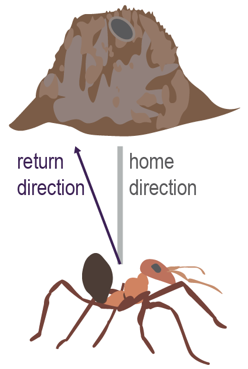

Desert ants of the genus *Cataglyphis* are known for their use of path integration (dead reckoning) to return to their nest. Disruption of visual orientation cues can result in deviations from the expected homewards direction.

In navigation experiments, return directions are often compared with the expected home direction to determine whether homeward navigation is perturbed. Here, we simulate example data (𝑛 = 20) generated from a distribution with a mean that differs from the expected direction (0°) by only 15°.

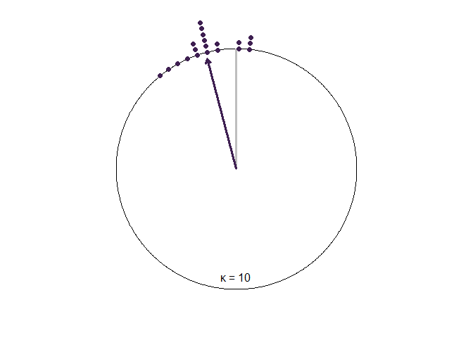

```r
ndata = 20 #sample size

# circular zero expected angle
c0 = circular(x = 0,
              units = 'degrees',
              rotation = 'clock',
              zero = pi/2)
#true mean angle
c15 = circular(x = -15,
              units = 'degrees',
              rotation = 'clock',
              zero = pi/2)

par(pty = 's') # square axes
par(mar = c(0,0,0,0)) # no margins

cd_divergence = DescriptCplot(m = -15, # population mean
                              k = 10, # high concentration
                              refline = 0, # expected direction
                              ndata = ndata,
                              mvcol = col_obs, #distr. mean same colour as observations
                              sdcol = NA, # don't plot SD
                              denscol = NA, # don't plot prob. density
                              save_sample = TRUE)
```

A common short-cut to assess orientation in an expected direction is to use the v-test modification of the Rayleigh test for uniformity. This tests the hypothesis of uniformity against the alternative of clustering in some direction less than 90° from the expected direction. The data are very far from uniform ($\kappa = 10$), and the mean angle is very close to the expected angle (cosine similarity of `cos(rad(-15)) = 97%`), so the test is significant. Even so, the data show a trend away from the expected angle, 75% of points falling to the left of 0°.

```r
mean(cd_divergence < 0)#proportion left of 0°
```

```
## [1] 0.75
```

```r
rayleigh.test(cd_divergence, mu = c0)#v-test with 0° expected direction
```

```
##
##        Rayleigh Test of Uniformity
##        Alternative with Specified Mean Direction:  1.570796
##
## Test Statistic:  0.9502
## P-value:  0
```

We can gain more information about any potential differences between the mean direction and the expected angle by fitting a circular generalised linear model (GLM) that estimates the mean direction ($\mu$) for this dataset.